# 生成AIエージェントと始める計算論的精神医学

Claude Code Desktopハンズオン

専修大学 国里愛彦

2026-08-24

## 国里愛彦（くにさと よしひこ）

- 専修大学人間科学部心理学科 教授
- 専門：計算論的精神医学、認知行動療法
- 関心：うつ・不安の発生／維持メカニズム、心理療法の作用メカニズム、個性記述
- 本日は、**生成AIに分析用Notebookを作らせる方法**と、**研究者が確認すべき点**を扱う
- COI：特定企業との利益相反はない

Claude Code Desktopは分析者の代わりではなく、ファイルを読み、コードを作り、実行結果を返す**共同作業者**として使う。

## 今日のゴール

次の流れを自分で始められるようになることを目指す。

1. データの確認と再現可能なJupyter環境を用意する
2. データの記述統計・可視化を行うNotebookを生成する
3. Q-learningモデルを参加者ごとにフィッティングするNotebookを生成する
4. モデル比較・パラメータ／モデル回復・生成データによる確認を行うNotebookを生成する

**始めるにあたって:** 「Claude Code セットアップ手順（事前配布用）.pdf」を参考に、https://github.com/y66yamay/sample_datasets4tutorialのリポジトリをDLし、Claude Code Desktopで当該フォルダを開いた状態にする。

## Claude Codeでデータの入ったフォルダを開く

[figure not shown]

## 最初にフォルダの内容を確認する

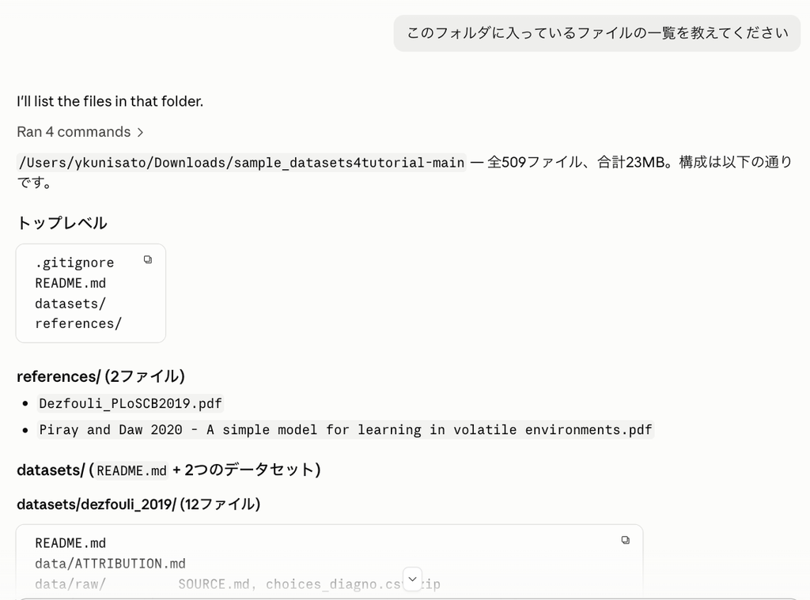

## AIエージェントと分析する基本ループ

1. 観察  
ファイル・課題

2. 依頼  
目的・判断

3. 実行  
Notebook作成

4. 確認  
データ・結果

- **人が決める：** 研究の問い、比較する仮説、許容できる処理、解釈
- **AIに任せる：** ファイル探索、Notebook作成、反復実行、図表の整形、定型的な確認
- **共同で行う：** 仮定の明文化、エラー確認、結果の批判的吟味

「解析して」だけでは、AIが目的・処理方法・確認方法を補ってしまう。LLMに結論を出させるのではなく、研究者が過程を確認できるNotebookを作らせる。

## 良い依頼は「5点セット」

| 要素 | 伝えること |
| --- | --- |
| 研究目的 | 何を明らかにしたいか |
| データ | 対象ファイル、使う列、参加者・試行などの単位 |
| 分析上の判断 | 欠測・除外・モデル・乱数シードをどう扱うか |
| 作るもの | 実行済みNotebook、表、図、レポートの保存先 |
| 確認方法 | 何を照合し、どの状態なら先へ進まないか |

## 本チュートリアルのプロンプト

- 本チュートリアルのプロンプトはやや丁寧目に書いているが、そこまで丁寧に書かなくても、生成AIの方で調べたり整理して作業する
- 生成AIと対話をしながらプロンプトを作らせる、といった進め方も有効
- このチュートリアルの内容はOpusでもSonnetでも機能することを確認しているが、モデルによって微妙に挙動は違う（モデル名だけでなくバージョンや時期によっても変わる…）
- モデルの挙動の不確実性を考慮して、コードが機能していることを確認できるポイントを定めておく

## Dezfouli et al. (2019)：概要

**目的：** 人の学習規則を研究者が先に仮定せず、行動データから柔軟に発見する。

- 健常・うつ病・双極性障害の101名が行った2択課題を用い、LSTM型RNNに行動・報酬履歴から**次の選択**を予測させた
- 未観測参加者への予測では、RNNがQ-learning系モデルやロジスティック回帰を上回った
- RNNへの入力履歴を操作すると、報酬直後の切替、過去の報酬による選択維持、臨床群に目立つ左右選択の振動が見つかった

本チュートリアルの目的はこの論文の結果全体の再現ではなく、**シンプルなQ-learningモデルの実装をClaude Codeで行う**こととする

[論文へのリンク](https://doi.org/10.1371/journal.pcbi.1006903)

## 参加者と2-armed bandit課題

**参加者：101名**

| 群 | n |
| --- | --- |
| 健常（HC） | 34 |
| 単極性うつ病（MDD） | 34 |
| 双極性障害（BD） | 33 |

**132,251試行**

**課題**

- 左右いずれかのキーを自己ペースで押す
- 40秒のブロックを12回
- 高確率側：0.25 / 0.125 / 0.08
- 低確率側：0.05
- 高確率側の左右を入れ替えた6条件を各2回

全群で高確率側をチャンスレベル以上に選んだが、臨床群は健常群より成績が低い傾向を示した（系列ごとの試行数は自己ペースのため可変）。

## 今回使う公開データ

sample_datasets4tutorial には、生データ・整形データ・前処理・辞書がまとまっている。

```
datasets/dezfouli_2019/
├── data/raw/choices_diagno.csv.zip
├── data/processed/trials.csv       # 1行 = 1試行
├── data/processed/subjects.csv     # 1行 = 1参加者
├── docs/data_dictionary.md
└── scripts/{preprocess,describe,make_report}.py
```

- 整形済み `trials.csv`を用いる：101名、132,251行、全員12系列
- `action` と `reward` に欠測なし
- 利用前に `SOURCE.md` と `ATTRIBUTION.md` も確認する

READMEや論文要約はデータ構造の理解に役立つが、分析に使うCSV自体の件数・列・欠測も必ず確認する。

## 列(変数)を間違えないように

| 役割 | 使用する列 | 注意 |
| --- | --- | --- |
| 個人・群 | `subject_id`, `group` | MDD / BD / HC |
| 系列・順序 | `sequence`, `step` | `step`は系列内で0始まり |
| 選択 | `action` | 0 = R1、1 = R2 |
| 結果 | `reward` | 0 / 1 |
| 補助情報 | `condition`, `block_half` | 実験条件・前後半 |

- `key` と `choice` は約49%の試行で一致しないため、意味を確認せず混用しない
- Q値は**参加者 × sequence**の境界でリセットする
- 年齢・性別・服薬などは公開ファイルに含まれない

ワイド型データならAIに「データ辞書を読んで」と依頼するだけでよいが、ロング型データだと**どの列をモデルに投入にするのかを人が指定**する必要もある

## Step 1：データ確認とJupyter環境構築

**ポイント：** AIに解析環境を用意させるだけでなく記録に残し、次回の自分が再現できる形にする。許可を求められたら、実行コマンドと変更先を確認してから承認する。

## Caude Codeの出力例

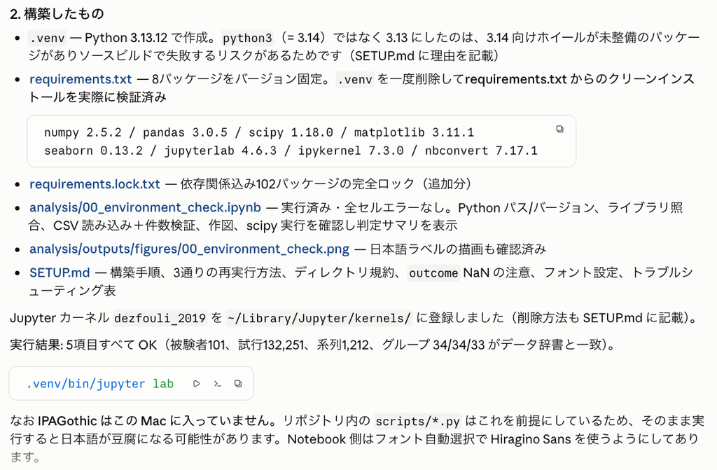

## 最初のチェックポイント

Claudeからの完了報告を読んで以下を確認

- `00_environment_check.ipynb` が `.venv` 内のPythonを使い、全セルをエラーなく実行済み
- `requirements.txt` と `SETUP.md` がある
- 新規ファイルは `analysis/` にある

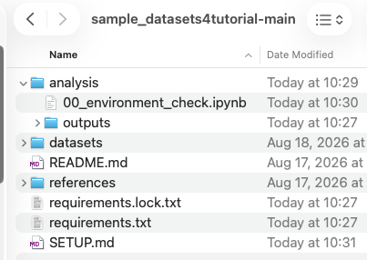

## 00_environment_check.ipynb

VSCodeなどのエディタで確認することができる。

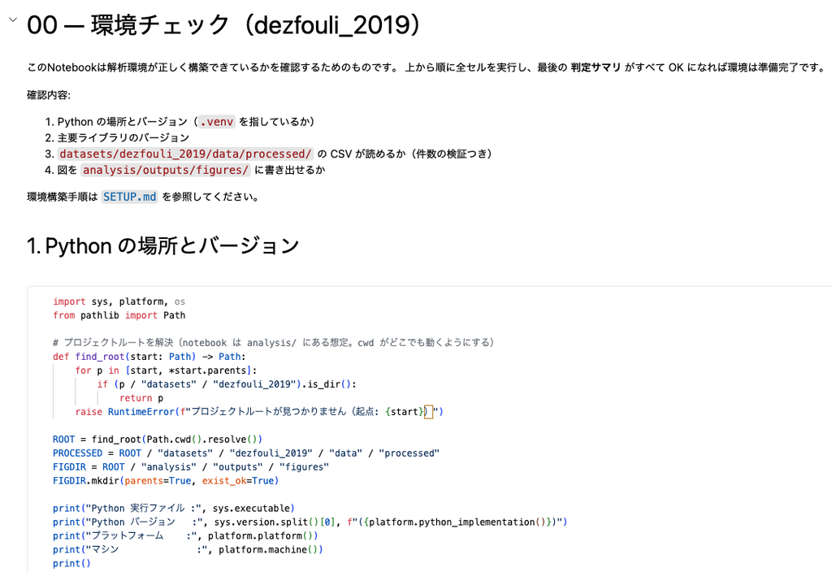

## Step 2：データチェックNotebookを生成する

## Caude Codeの出力例

データ辞書に誤りがあったが、問題なさそう

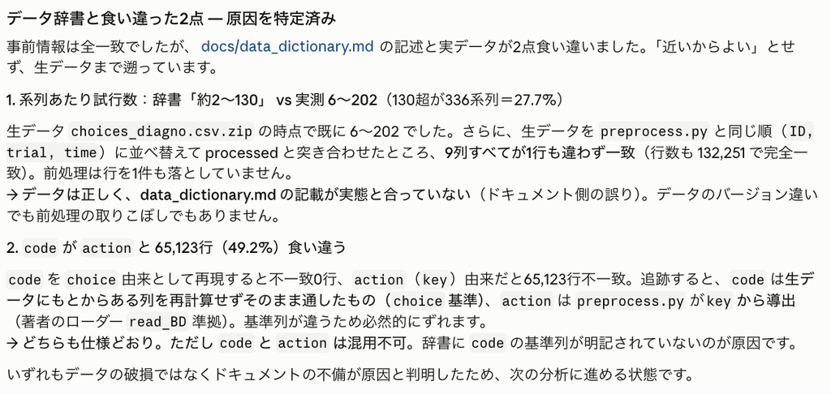

## Step 3：記述統計Notebookを生成する（1/2）

**観測単位は参加者。** 132,251試行を独立サンプルとして扱うと、疑似反復になる。

## Caude Codeの出力例

細かなデータチェックをしてくれている。

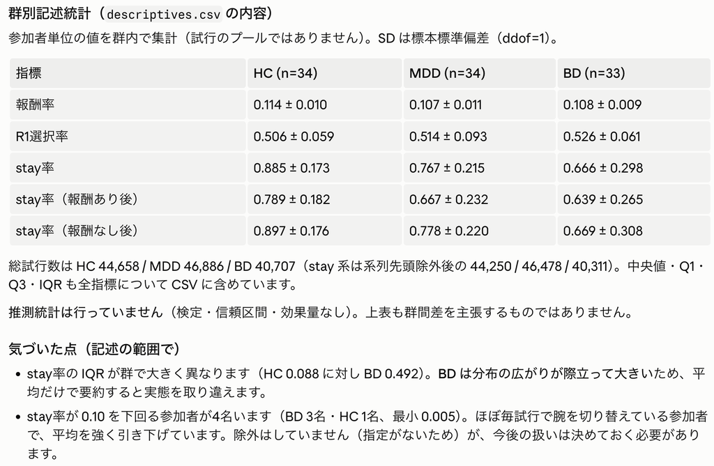

## Step 3：可視化Notebookを生成する（2/2）

論文の重要なモデル非依存パターンは、**直前の報酬と次のstay／switchの関係**である。モデルを当てる前に見る。

## 出力されるプロット例

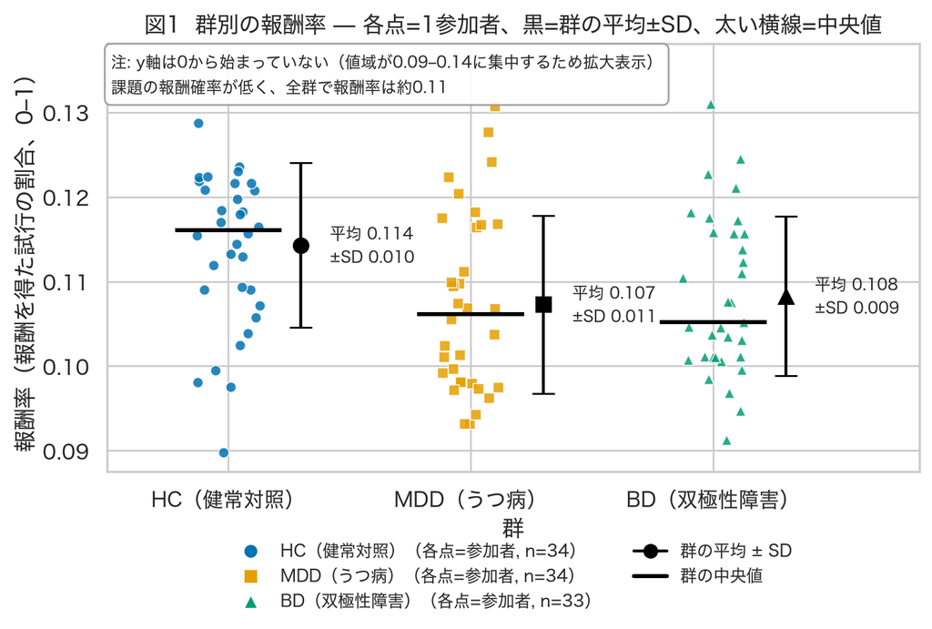

## 出力されるプロット例

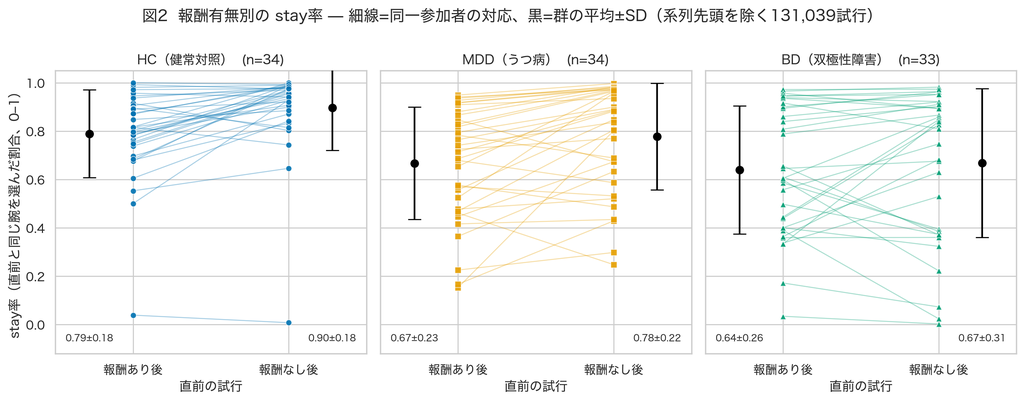

## 生成された分析をレビューする

**データ**

- 個人・系列・試行の単位は正しいか
- 欠測と除外数が残っているか
- 系列内で試行順に並べてから、直前試行と対応付けたか
- 系列境界をまたいでいないか

**集計・再現性**

- 試行を独立扱いしていないか
- 図に個人差が見えるか
- 入力ファイル、除外、乱数シード、ソフトウェアのバージョンが記録されたか
- カーネル再起動後に全セルを上から実行して同じ成果物になるか

全コードを全て理解できなくてもよいが、**入力 → 変換 → 出力**と、研究上重要な境界条件は説明できるようにする。

## Q-learningモデル

Q-learningは、選択肢ごとの価値 $Q(a)$ を経験から更新する最小モデルになる。

選択  
a<sub>t</sub>

結果  
r<sub>t</sub>

価値更新  
Q<sub>t+1</sub>

次の選択  
P(a<sub>t+1</sub>)

- 学習率 $\alpha$：新しい結果をどれくらい強く反映するか
- 逆温度 $\beta$：価値差をどれくらい一貫して選択へ反映するか
- 観測されるのは選択と報酬、$Q$ と予測誤差はモデル内の潜在変数

## 価値更新と選択確率

選んだ行動だけを、報酬予測誤差で更新する。

$$\delta_t=r_t-Q_t(a_t), \qquad
Q_{t+1}(a_t)=Q_t(a_t)+\alpha\delta_t$$

$$Q_{t+1}(a')=Q_t(a')\quad(a'\neq a_t)$$

次の選択はsoftmaxで確率化する。

$$P(a_t=1)=
\frac{\exp\{\beta Q_t(1)\}}
{\exp\{\beta Q_t(0)\}+\exp\{\beta Q_t(1)\}}$$

- $0<\alpha<1$、$\beta\ge 0$ ($\beta=0$ ならランダム)
- 今回は、$Q_0(0)=Q_0(1)=0.5$ とし、系列ごとにリセット

## モデル比較：予測誤差の正負で学習率を分ける

- 今回、モデル比較のために２つのモデルを用意する

| モデル | パラメータ | 更新 |
| --- | --- | --- |
| 単一学習率モデル（M1） | $\alpha,\beta$ | 常に$\alpha$ |
| 正負別学習率モデル（M2） | $\alpha_+,\alpha_-,\beta$ | $\delta_t\ge0$なら$\alpha_+$、それ以外は$\alpha_-$ |

M1は、M2の $\alpha_+=\alpha_-$ という特殊例である。

「正／負」は報酬の有無ではなく、**現在の期待に対する予測誤差の符号**である。

## 最尤推定によるフィッティング

参加者 $s$ の実際の選択に関してモデルが計算した確率を使って負の対数尤度計算する。負の対数尤度が最も小さなパラメータを推定する。

$$\mathrm{NLL}_s(\theta)
=-\sum_{t=1}^{T_s}\log P(a_{s,t}\mid\text{過去},\theta)$$

| 指標 | 式 | よい値 |
| --- | --- | --- |
| AIC | $2k+2\mathrm{NLL}$ | 小さい |
| BIC | $k\log n+2\mathrm{NLL}$ | 小さい |

- 参加者ごと・モデルごとに推定する(M1は $k=2$、M2は $k=3$ )
- 局所解対策として複数の初期値から最適化する

## Step 4：フィッティングNotebookを生成する

## 研究者が確認するポイント

- `subject_id, sequence, step` で並べ、`sequence` ごとに $Q$ をリセットする
- 更新前Qで選択確率を計算 → 対数尤度を加算 → 報酬で更新、の順を守る
- 人工データでQ値と尤度を照合し、$\alpha_+=\alpha_-$ でM1・M2の尤度一致を確認する
- NLLが有限、試行数＝使用選択数、パラメータが範囲内かを確認し、推定失敗・学習率の0／1付近・初期値間の不一致を把握する
- 入力・データのバージョン・乱数シード・実行環境を記録し、再起動後に全セルを実行する

パラメータ推定ができただけでは、実装の正しさは保証されない。

## Claude Codeの出力例

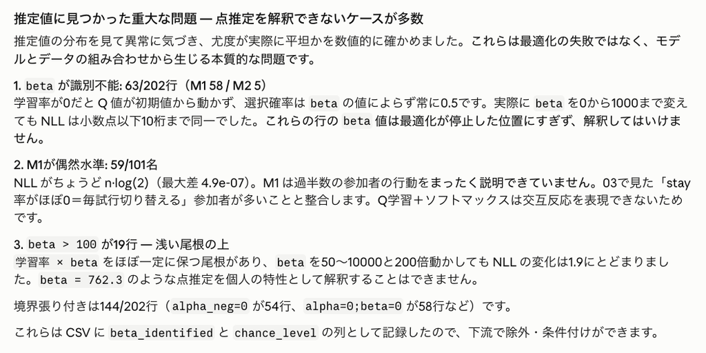

## NotebookをHTMLで確認する

- HTMLにすると、VSCodeやJupyterを起動せず、説明・コード・表・図・確認結果をブラウザで順に読める。

HTMLは確認用の写しであり、分析の本体は `.ipynb`。

## HTML出力結果

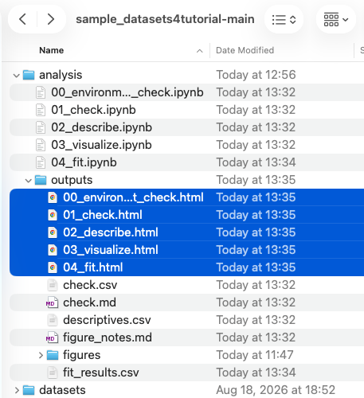

## 「Ten Simple Rules」

行動データへの計算論モデリングでよく参照されるルール(Wilson & Collins, 2019)

1. 良い実験を設計する
2. 良いモデルを設計する
3. **まずシミュレーションする**
4. パラメータをフィットする
5. パラメータリカバリーを確認する
6. モデルを識別できるか確認する（モデルリカバリー）
7. モデル非依存分析後に実データへ適用
8. 選ばれたモデルが実データの特徴を再現するか確認する
9. 確認後に潜在変数・個人差を分析する
10. 工程・分布・コード・データを報告する
- ガイドライン論文を生成AIに読ませて、解析作業をさせることができる（今回は含めないがパラメータリカバリーやモデルリカバリーなどの検討を依頼できる）

Wilson & Collins (2019), [Ten simple rules for the computational modeling of behavioral data](https://elifesciences.org/articles/49547)

## **演習：**Gagne et al. (2020)

https://github.com/y66yamay/sample_datasets4tutorialには、Gagne et al. (2020)のデータも含まれているので、ご自身でClaude Codeを試してみましょう！

**問い：** 環境の随伴性が変動するとき、内在化症状が高い人は学習率を十分に調整できるか？

- stable：一方が75%、他方が25%で固定
- volatile：80% / 20%の高確率側が20試行ごとに交替
- 実験1：報酬／電気刺激、論文の主解析は $n=86$
- 実験2：オンラインの報酬獲得／損失、$n=147$
- 主結果：一般内在化因子が高いほど、変動環境で**良い結果後に学習率を上げる反応**が弱く、実験2でも概念的に再現

[論文リンク](https://doi.org/10.7554/eLife.61387)

## おまけ：手順を再利用するSkillの活用

Skillは、繰り返し使う手順や確認項目をまとめたフォルダであり、`SKILL.md` が入口になる。Claude Codeは名前と説明から使うSkillを選び、必要なときに本文を読み込む。

**通常のプロンプト**

- その会話の依頼に使う
- 毎回、必要な条件を伝える
- 今回固有の作業に向く

**Skill**

- 関連する依頼で再利用できる
- 手順、成果物、確認・停止条件を保てる
- `/skill-name` で呼び出せる

プロジェクト用Skillは `.claude/skills/<skill-name>/SKILL.md` に置き、Gitで共同研究者と共有できる。

会話をそのまま保存するのではなく、**別の研究にも使える判断と手順**を残す。

[Claude Code Docs: Skills](https://code.claude.com/docs/en/slash-commands)